# Saturn: Rings, Shadows and Strange Moons

Unit 2: Night Sky · the featured planet · Astronomy

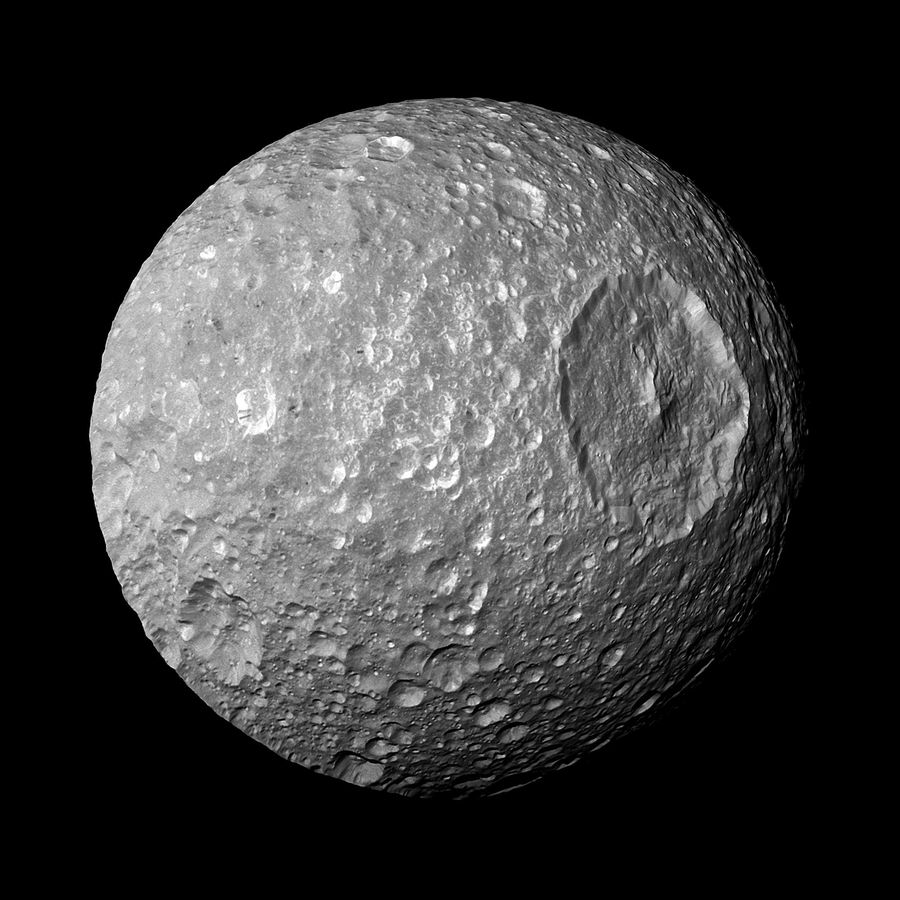

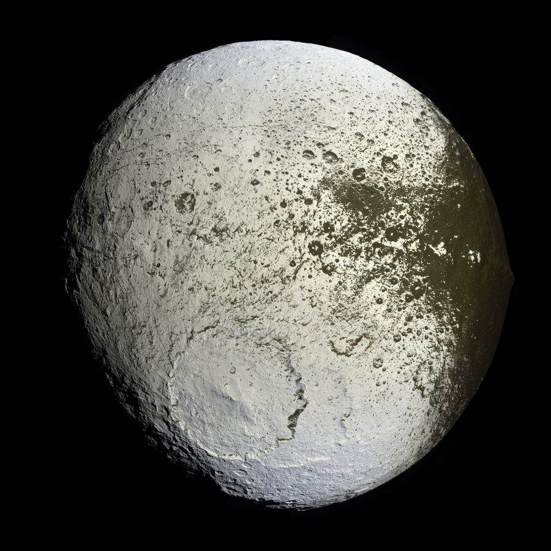

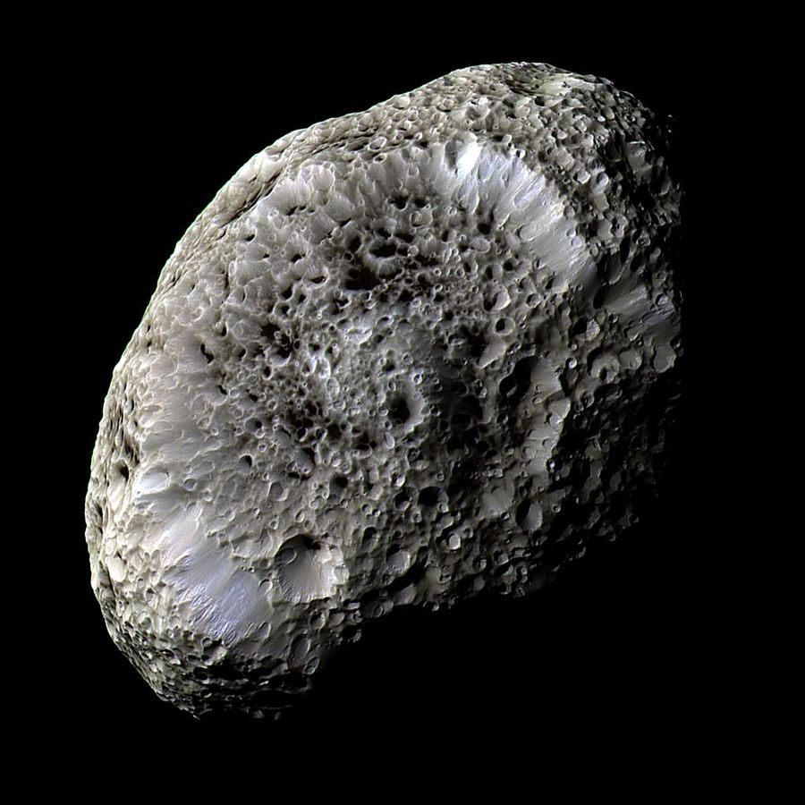

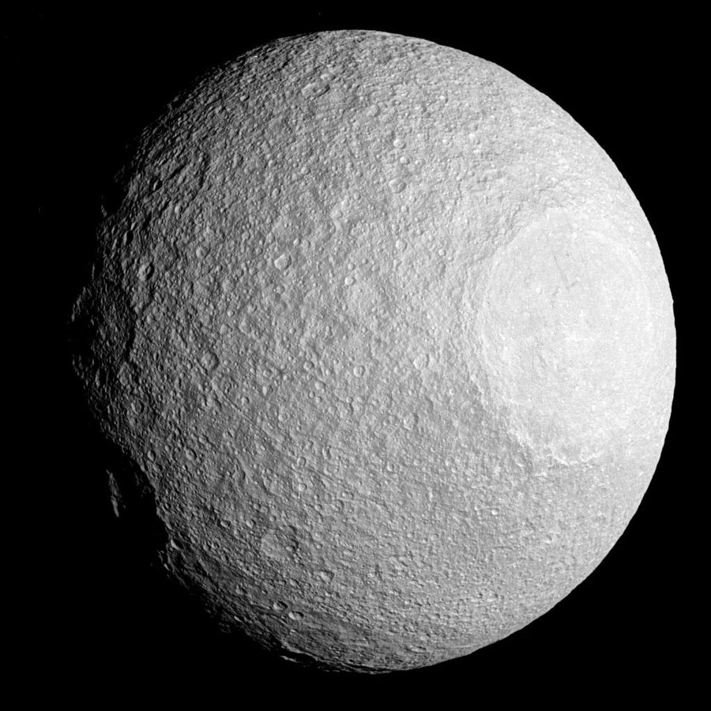

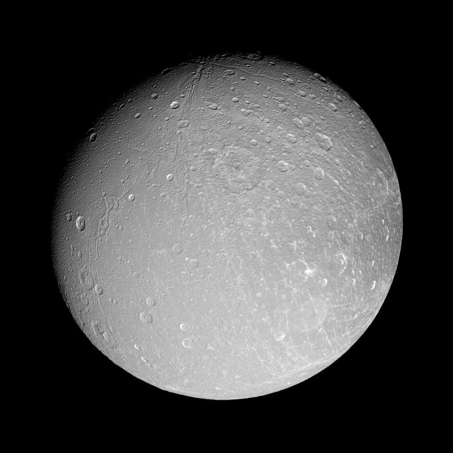

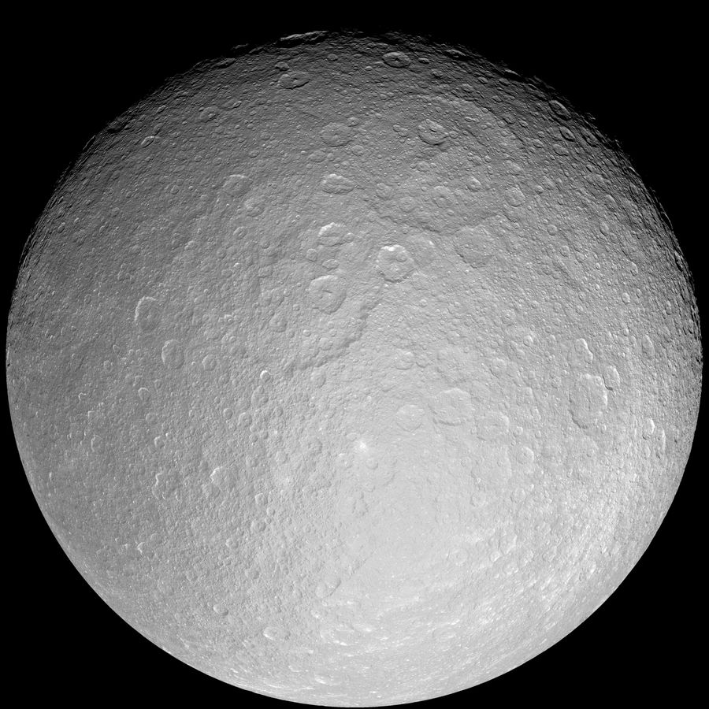

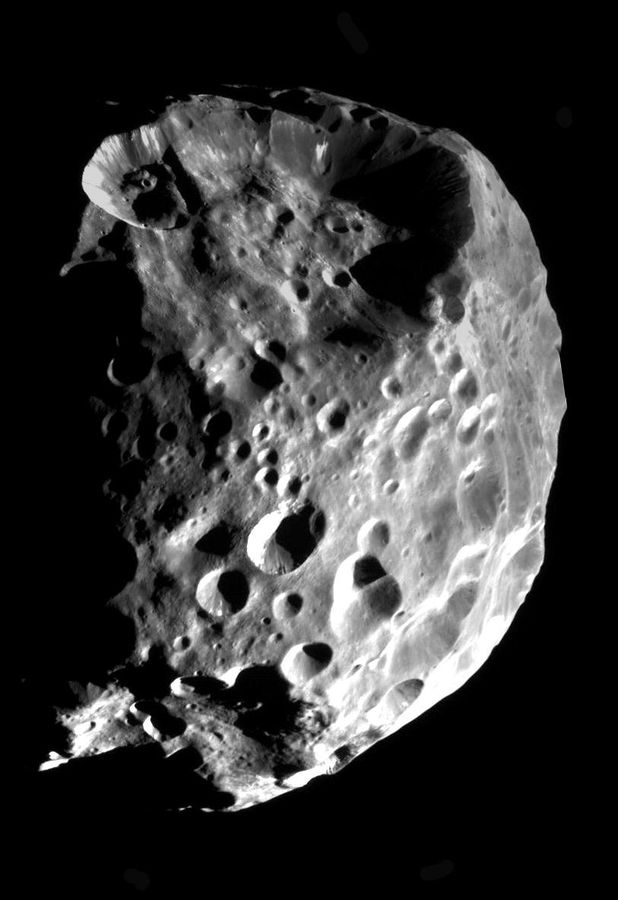

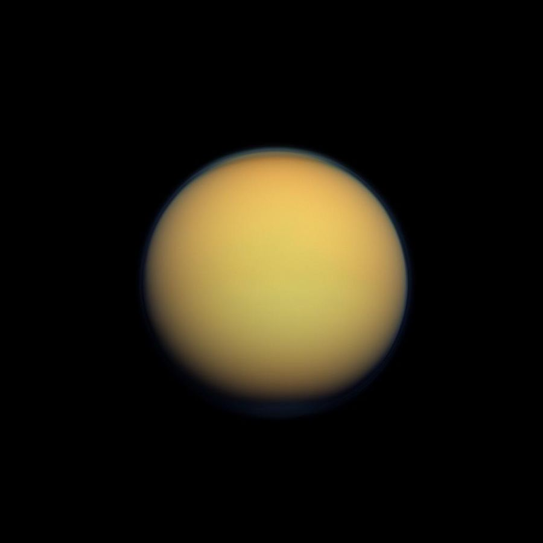

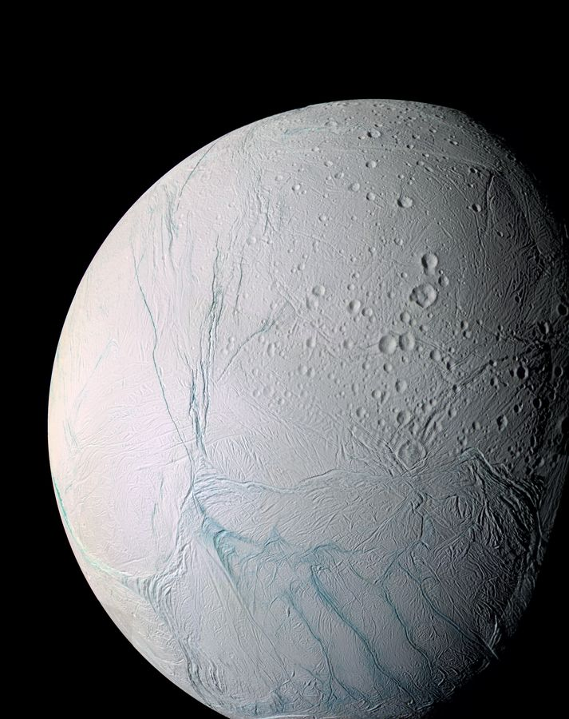

[interactive chart not shown]

In July 1610 Galileo pointed his small telescope at Saturn and saw something no one could explain: a planet made of **three bodies**, a big one with a smaller one stuck to each side. Two years later the companions were **gone**. By 1616 they were back, now looking like handles or "ears". Nobody understood them until 1655, when Christiaan Huygens worked out that Saturn wears a thin, flat **ring** that never touches it. When the ring turns edge-on to us, it all but vanishes.

This fall you can see what puzzled Galileo. The rings turned edge-on to Earth in March 2025, and tonight they are tilted only about **6½°**: a thin bright line through the planet. Saturn is high in the south-east after dark all fall.

Today: name the parts of the rings, find out what they're made of, and meet the moons that shape them, then Titan, Enceladus and what is inside Saturn.

Tilt computed for each date with Astronomy Engine; rings drawn from Cassini's measurements. Open the Saturn app to fly around it and see tonight's moons.

Saturn through the years: drag the year

Year

Through Galileo's telescope

[interactive chart not shown]

[figure not shown]

**Galileo's letter of 30 July 1610**: Saturn drawn as "oOo", one big body with a smaller one on each side. (The green box was added by the archive, not Galileo.) Galileo Galilei, Biblioteca Nazionale Centrale di Firenze, via Museo Galileo; public domain

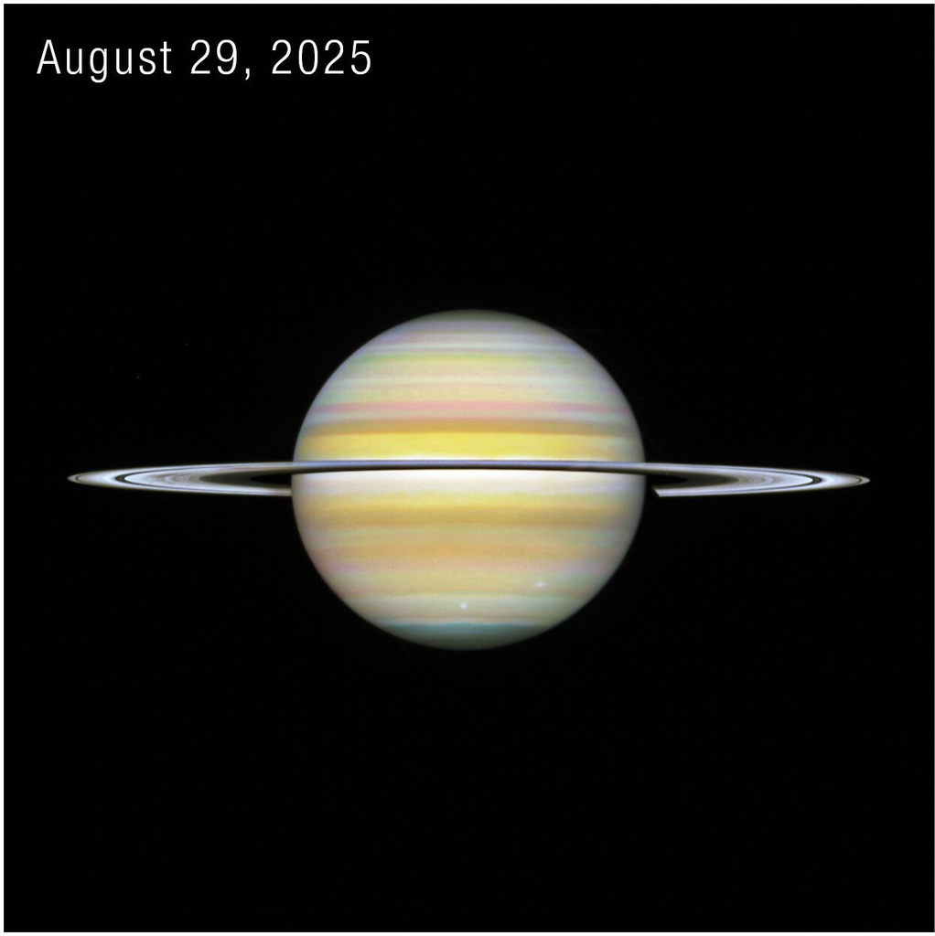

**Saturn from Hubble, 29 August 2025**, five months after the rings turned edge-on: what you'll see in a telescope this fall, only sharper. NASA, ESA, STScI, A. Sánchez-Lavega, A. Simon, M. Wong; processing A. Pagan (STScI); CC BY 4.0

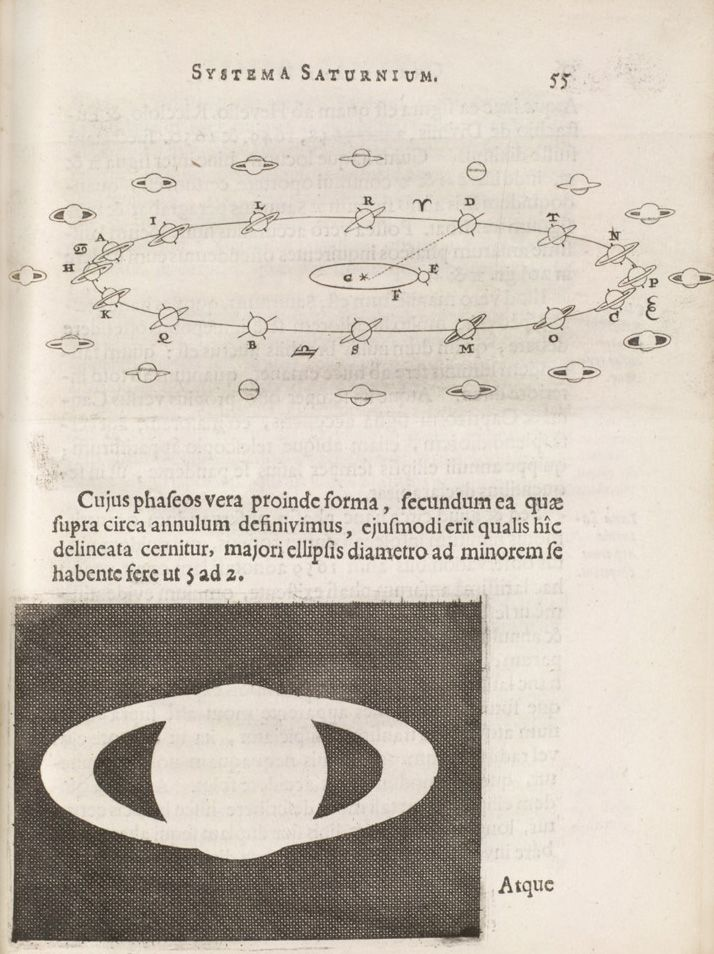

**Huygens' answer, 1659**: a thin flat ring, tilted to Saturn's orbit, so we see it from above, edge-on, then from below as Saturn goes around the Sun. Christiaan Huygens, *Systema Saturnium*; Smithsonian Libraries; public domain

## Saturn at a glance

[figure not shown]

Saturn from high above its north pole: the hexagon at the top, and the planet's shadow falling across the rings. NASA/JPL-Caltech/Space Science Institute/Cornell

🌍

Size

60,268 km to the cloud tops at the equator

⚖️

95 Earths

Mass

second only to Jupiter

🛁

0.69 g/cm³

Bulk density

less than water: in a big enough bathtub it would float

☀️

9.5 AU

Distance from the Sun

sunlight takes about 79 minutes to get there

🌀

10 h 33 min

One day

measured from waves in the rings

📅

29.5 years

One year

so its seasons each last about 7 of ours

💍

273,000 km

Main rings, edge to edge

about 21 Earths across, but only about 10 m thick

🌙

285 moons

Known moons

more than any other planet (285 confirmed by March 2026); Titan is bigger than Mercury

## Seven things to explore

Click a tile. You don’t need all seven.

[figure not shown]

1

What are the rings?

ice, and a lot of it

[figure not shown]

2

Gaps and shepherds

little moons that sweep

[figure not shown]

3

In Saturn's shadow

the view with the Sun behind

[figure not shown]

4

Titan

rain, rivers and seas of methane

[figure not shown]

5

Enceladus

geysers from a hidden ocean

[figure not shown]

6

Inside Saturn

a hexagon, helium rain, and floating

[figure not shown]

7

Cassini's Grand Finale

22 dives, then a plunge

← scroll the tiles →

### What are the rings made of?

Saturn's rings are not solid. They are billions of separate pieces of **water ice**, each on its own orbit around Saturn, like a swarm of tiny moons. The pieces range from **dust** to chunks as big as a **house**; most are snowball- to boulder-sized. The ice is so clean that the rings reflect most of the sunlight that hits them, which is why they shine.

The main rings are about 273,000 km across but only about **10 m thick**: thinner, for their size, than a sheet of paper. Each named part (the D, C, B and A rings, the Cassini Division, the Encke and Keeler Gaps, and the faint F, G and E rings) is a band where the pieces are packed more or less tightly.

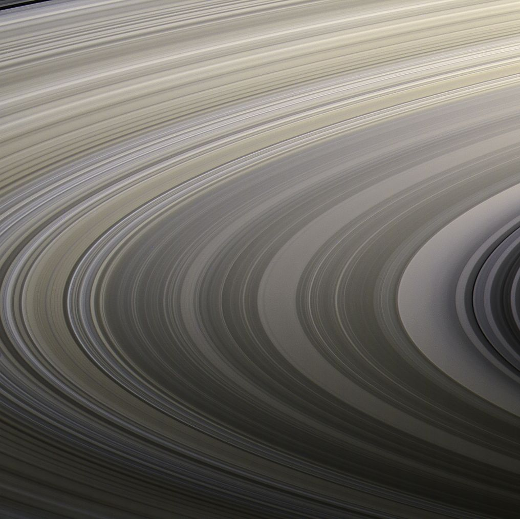

**"Gravity's Rainbow"**: the main rings in natural colour from Cassini, each band a different mix of ice and dust. NASA/JPL-Caltech/Space Science Institute

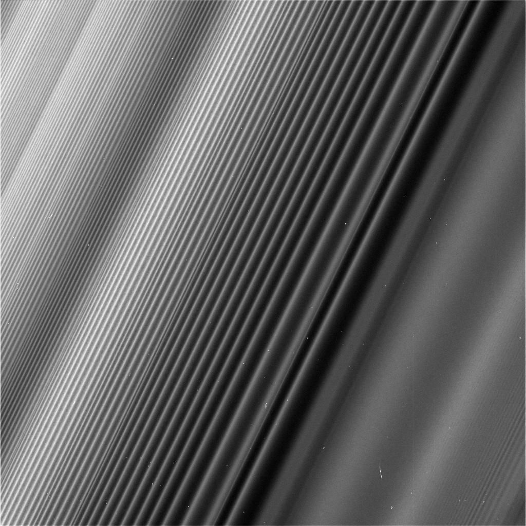

**Up close**, from the Grand Finale: the ripples are a spiral wave in the B ring, raised by the moon Janus through a 2 : 1 resonance (see tile 2). NASA/JPL-Caltech/Space Science Institute

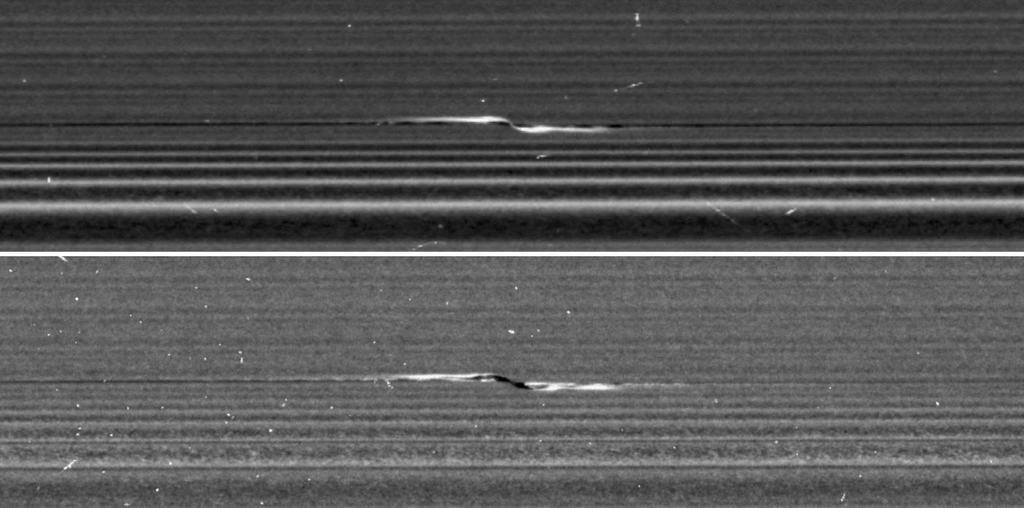

**The closest we've come to seeing a single piece**: a "propeller" named Santos-Dumont, photographed by Cassini on 21 February 2017 from the sunlit side (top) and the unlit side (bottom). The moonlet in the middle has about the mass of a 1 km snowball, but it is too small to show up even at 207 m per pixel. We see only the twisted wake it stirs in the ring, about 70 km long (our estimate, measured off the picture), with a 2 km gap along it. No single ring particle has ever been photographed: even this is a thousand times too coarse to see a snowball. The specks are cosmic-ray hits. NASA/JPL-Caltech/Space Science Institute

Name the parts: tap a band

[interactive chart not shown]

This is a slice across the rings from Saturn outward, drawn from Cassini's measurements: the taller the bar, the more ice there is to block starlight. Tap any band to name it.

Measure: shrink the rings to a sheet of paper

The main rings are about $2.7\times10^{8}$ m across and about 10 m thick. A sheet of paper is about 0.1 mm thick. Shrink the rings until they are as thin as the paper. How wide would the sheet be?

**Reveal**

Shrink factor $= \dfrac{10\ \text{m}}{1\times10^{-4}\ \text{m}} = 1\times10^{5}$. Scaled width $= \dfrac{2.7\times10^{8}\ \text{m}}{1\times10^{5}} = \boxed{2.7\ \text{km}}$. A sheet of paper about 27 football fields wide: that is how flat the rings are.

Order of magnitude: how many pieces?

Cassini weighed the rings by flying between them and Saturn: about $1.5\times10^{19}$ kg of ice. If every piece were a ball of ice 1 m across, how many pieces would there be? **Guess the order of magnitude first.**

Size of a typical piece**1 m**

[interactive chart not shown]

Pick a guess to unlock the slider.

One ball of ice of diameter $d$ has mass $m = \rho\,\tfrac{\pi}{6}d^3$, with ice's density $\rho = 0.92$ g/cm³ $= 920$ kg/m³. Then the number of pieces is $N = \dfrac{M}{m}$.

**Are the rings young?** The ice looks surprisingly clean. Dust from space falls on the rings all the time and should darken them, so clean rings suggest they are young: perhaps a few hundred million years old, which would make them younger than many dinosaurs. Other scientists argue that rings can stay clean for billions of years. This is still being argued. One thing is measured: ice is slowly **raining from the rings into Saturn**, so they will not last forever. We live in a good time to have rings.

### Gaps and shepherd moons

Some of the rings' sharpest edges are made by moons. Little **Pan** (28 km across) orbits inside the **Encke Gap** and sweeps it clear; tinier **Daphnis** keeps the **Keeler Gap** open and raises waves on its edges. The narrow **F ring** is herded by two **shepherd moons**: Prometheus just inside it and Pandora just outside.

Bigger moons farther out work by **resonance**: a small tug that keeps arriving at the same place at the same time, like pushing a swing at the right moment each time it comes back. A ring piece that goes around Saturn exactly twice for each orbit of the moon **Mimas** gets tugged at the same spot every second lap, and the tugs add up. That is why the B ring stops so sharply at the inner edge of the Cassini Division.

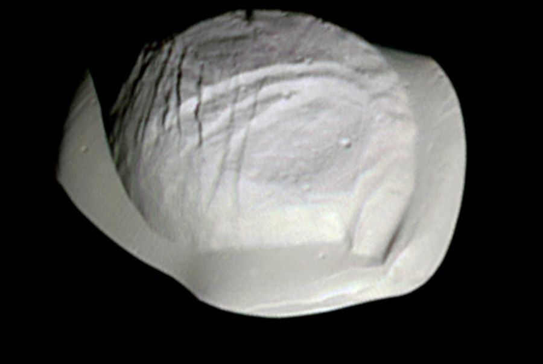

**Pan**: a ridge of ring material piled around its middle makes it look like a flying saucer. NASA/JPL-Caltech/Space Science Institute

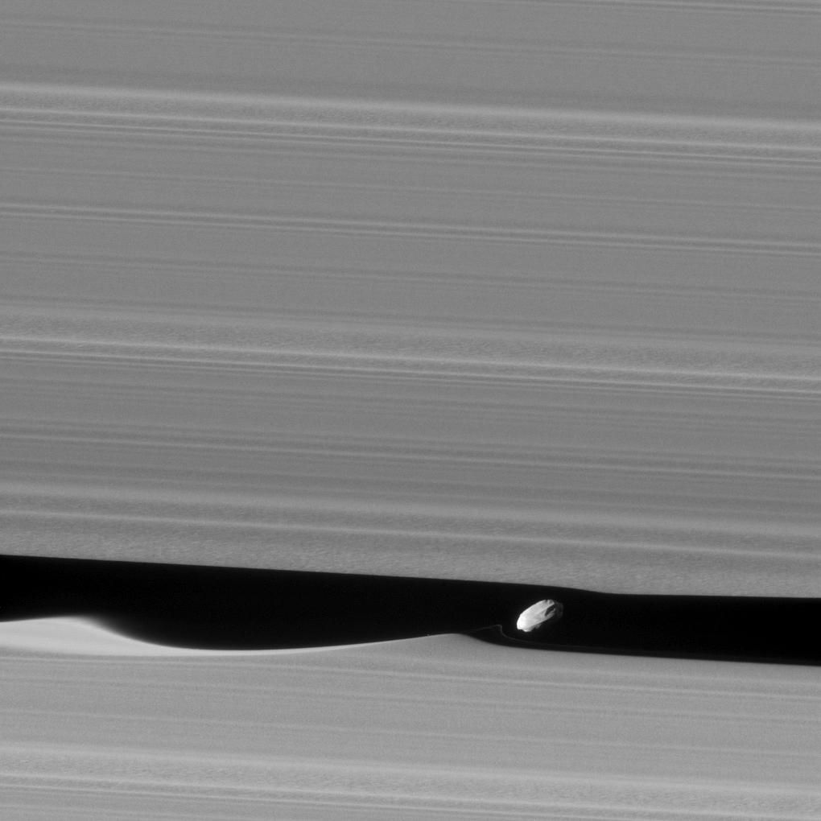

**Daphnis** in the Keeler Gap, making waves in the ring edge as it passes. NASA/JPL-Caltech/Space Science Institute

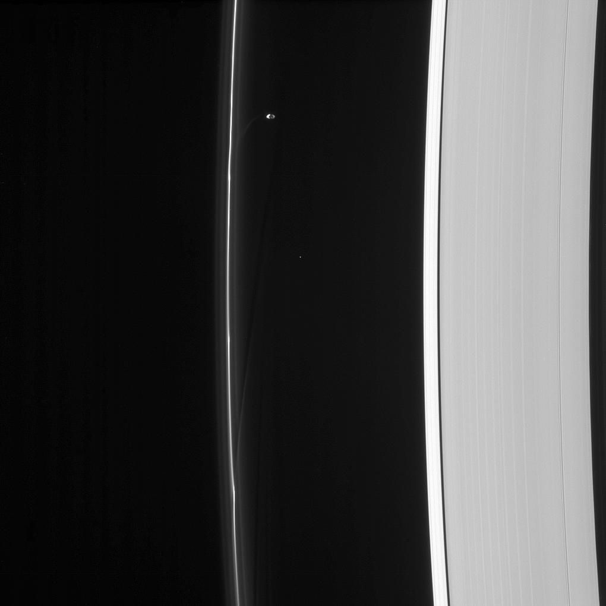

**Prometheus** beside the F ring, and the dark channel it carves each time it swings close. NASA/JPL-Caltech/Space Science Institute

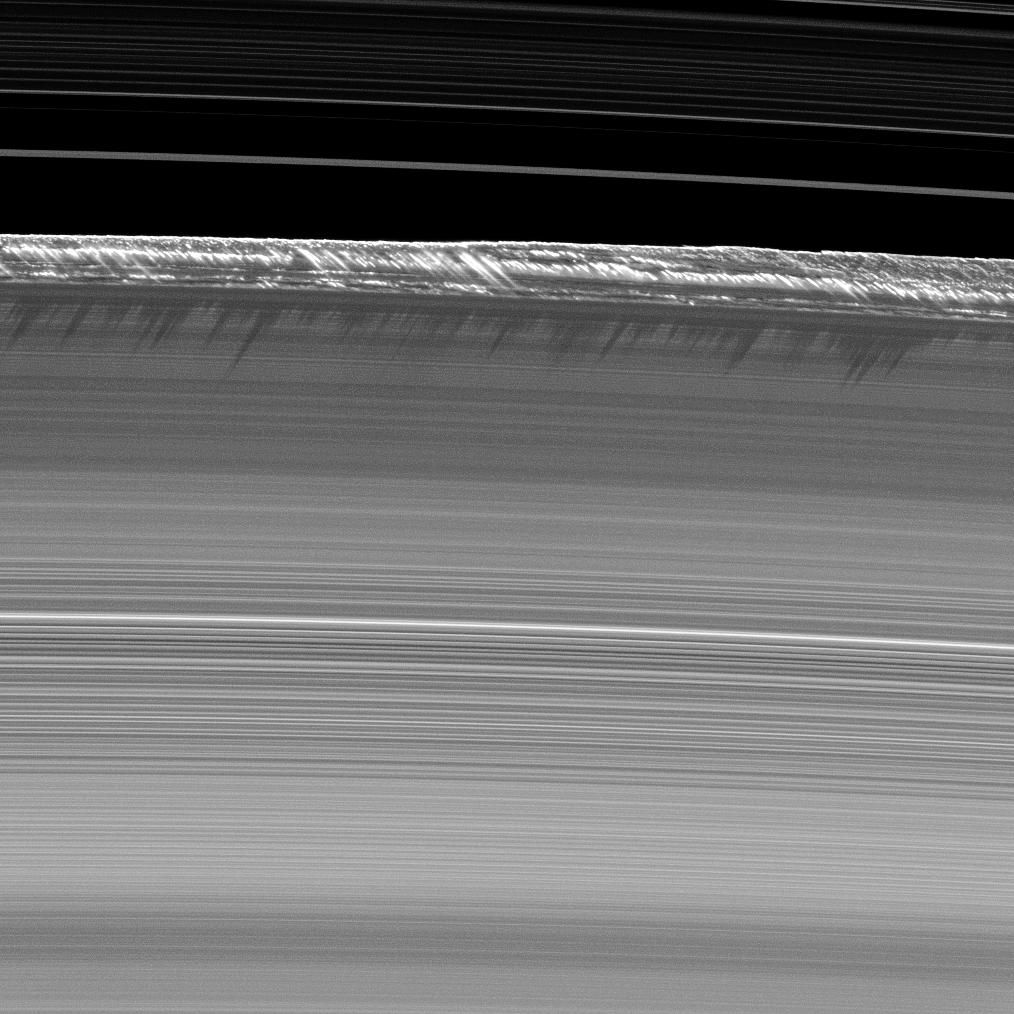

**Equinox, August 2009**: with the Sun exactly edge-on to the rings, piled-up ring material at the edge of the B ring casts long shadows. It rises kilometres above a ring only about 10 m thick. NASA/JPL/Space Science Institute

Ride along with Pan: watch the gap's edges

[interactive chart not shown]

Speed**×1**

Computed, not drawn: each dot is a ring piece moving under Saturn's gravity plus Pan's (Hill's equations, in the frame that moves with Pan). Pieces inside Pan's orbit go a little faster and pass it on one side; pieces outside go slower and pass on the other. Watch the waves that appear on the edges after the pieces pass Pan.

Measure: where is the 2 : 1 with Mimas?

Mimas orbits $1.86\times10^{5}$ km from Saturn's centre. Kepler's third law in relative form is $\left(\dfrac{p}{p_{\rm M}}\right)^2 = \left(\dfrac{a}{a_{\rm M}}\right)^3$. Find the orbit $a$ where a ring piece's period $p$ is exactly half of Mimas's.

**Reveal**

$\left(\tfrac12\right)^2 = \left(\dfrac{a}{a_{\rm M}}\right)^3 \Rightarrow \dfrac{a}{a_{\rm M}} = \left(\tfrac14\right)^{1/3} = 0.630$, so $a = 0.630\,(1.86\times10^{5}\ \text{km}) = \boxed{1.17\times10^{5}\ \text{km}}$. The B ring ends at 117,500 km: right there. (Saturn's flattened shape nudges the real resonance about 0.3% farther out.)

Watch Mimas open the Cassini Division yourself in the app's Resonances mode.

### In Saturn's shadow

In 2006 Cassini slipped into Saturn's shadow and looked back toward the hidden Sun. The view surprised everyone. The rings glowed in colours no one had seen, faint rings that are almost invisible from the sunny side lit up, and Cassini found two new ones. Tiny grains of dust and ice **scatter light forward**, the way dust in a sunbeam shows up best when you look toward the window. Big chunks of ice do the opposite: they look brightest with the Sun behind you.

Look closely at the upper left of the picture, just above the bright rings and inside the faint outer ring: the small pale dot is **Earth**. In 2013 Cassini did it again, and this time people on Earth were told in advance to go outside and wave: "The Day the Earth Smiled".

[figure not shown]

**In Saturn's Shadow**, 15 September 2006. Earth is the pale dot just above the bright rings, upper left. NASA/JPL/Space Science Institute

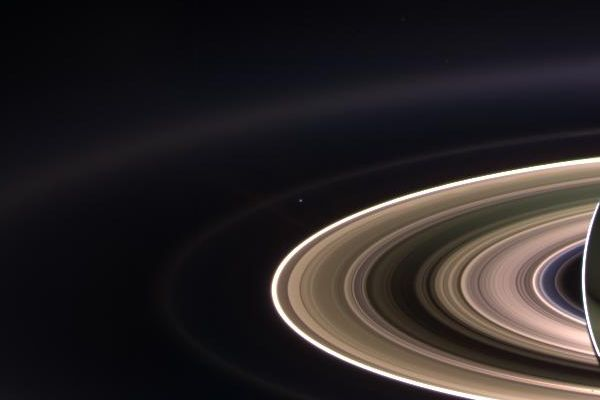

**Zoomed in**: that dot is every person who has ever lived, seen from about 1.5 billion km. NASA/JPL/Space Science Institute

[figure not shown]

**The Day the Earth Smiled**, 19 July 2013: Earth and the Moon from Saturn, 1.4 billion km away. NASA/JPL-Caltech/Space Science Institute

Predict first: which ring brightens when you look toward the Sun?

Where you stand

[interactive chart not shown]

Make a prediction to unlock the slider.

Measure: how old is the picture of Earth?

On 19 July 2013 Earth was 9.6 AU from Saturn (computed). Light from Earth had to cross that to reach Cassini (1 AU $= 1.5\times10^{11}$ m, $c = 3\times10^{8}$ m/s). How long did it take?

**Reveal**

$\Delta x = 9.6 \times 1.5\times10^{11}\ \text{m} = 1.44\times10^{12}$ m, and $\Delta t = \dfrac{\Delta x}{c} = \dfrac{1.44\times10^{12}\ \text{m}}{3\times10^{8}\ \text{m/s}} = 4.8\times10^{3}\ \text{s} = \boxed{80\ \text{min}}$. Cassini saw Earth as it was more than an hour earlier, and every command from Earth took that long to arrive.

### Titan: rain, rivers and seas of methane

Titan is Saturn's biggest moon, larger than the planet Mercury, and the only moon with a thick atmosphere: the air pressure on the ground is about **1½ times** Earth's. It is very cold, about **−179 °C**, so the water is frozen as hard as rock. Instead, **methane** (natural gas, CH₄) does what water does on Earth: it forms clouds, falls as rain, carves rivers, and fills **lakes and seas** near the north pole. Titan is the only other world we know with rain falling on the ground and liquid standing in lakes.

The orange haze is made by sunlight. High up, ultraviolet light breaks apart nitrogen (N₂) and methane. The broken pieces stick together into bigger molecules, like ethane (C₂H₆), then longer and longer chains, until they form tiny orange-brown specks called **tholins**. The specks are the haze. Slowly they drift down and pile up; Titan's huge dunes are probably made of them.

[figure not shown]

**Titan, backlit**: all haze, no ground. The thin blue ring at the edge is a layer of haze high above the rest. NASA/JPL-Caltech/Space Science Institute

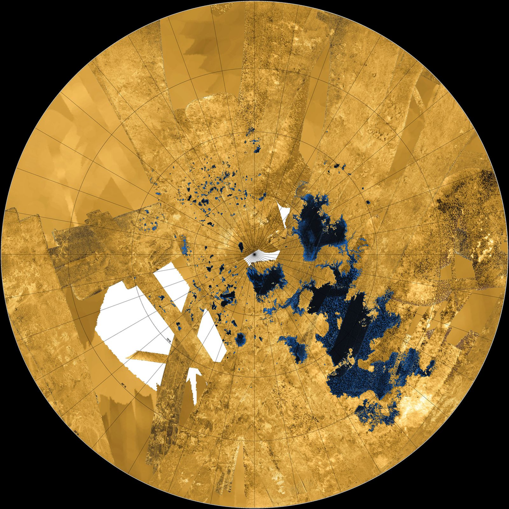

**Seas near the north pole**, mapped by Cassini's radar through the haze. Kraken Mare is the biggest. NASA/JPL-Caltech/ASI/USGS

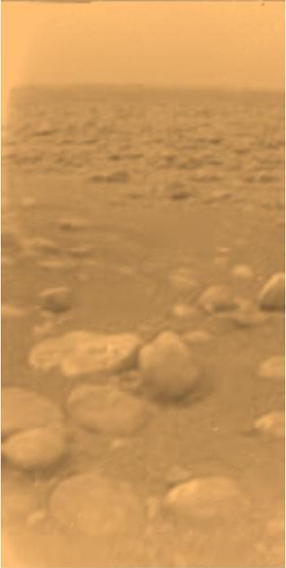

**On the ground**: the Huygens probe landed on 14 January 2005, on a plain of rounded pebbles of ice. NASA/JPL/ESA/University of Arizona

Titan's methane cycle, step by step

[interactive chart not shown]

Measure: how much would you weigh on Titan?

Titan's mass is $1.35\times10^{23}$ kg and its radius is $2.575\times10^{6}$ m. Find $g = \dfrac{GM}{r^2}$ with $G = 6.67\times10^{-11}$, and compare with Earth's 9.8 m/s².

**Reveal**

$g = \dfrac{(6.67\times10^{-11})(1.35\times10^{23})}{(2.575\times10^{6})^2} = \boxed{1.36\ \text{m/s}^2}$, about $\tfrac{1}{7}$ of Earth's. A 150 lb student would weigh about 21 lb. With gravity that weak and air about four times as dense as ours, NASA says you could strap wings to your arms, flap, and fly.

[figure not shown]

**Dragonfly**, NASA's drone for Titan, is due to launch in 2028 and fly from place to place across the dunes, ending at Selk crater. NASA/Johns Hopkins APL/Steve Gribben

**Still a mystery.** Sunlight destroys methane in Titan's air, and the ethane it makes cannot turn back into methane, so it collects in the lakes. At today's rate the methane should run out in tens of millions of years. So either something inside Titan keeps resupplying it, or we happen to live in the era when Titan has rain. Nobody knows which.

### Enceladus: geysers from a hidden ocean

Enceladus is small, only 504 km across, and covered in fresh, bright ice. In 2005 Cassini found jets of water vapour and ice grains shooting out of four long cracks near its south pole, the **tiger stripes**. Under the ice is a salty **ocean** that covers the whole moon, and the jets are that ocean spraying into space. Some of the spray falls back as snow; the rest escapes and feeds Saturn's wide, faint **E ring**.

What keeps the water liquid is **tidal heating**, the same squeezing that heats Jupiter's moon Io. Enceladus's orbit is slightly oval, and the moon Dione keeps it that way: Enceladus goes around exactly twice for each orbit of Dione (a 2 : 1 resonance again). So once every orbit Saturn squeezes and stretches Enceladus, and the flexing makes heat. Cassini even saw the jets get **brighter** when Enceladus is farthest from Saturn, just when the tides pull the tiger stripes open.

[figure not shown]

**The plumes**, backlit by the Sun so the ice grains glow. NASA/JPL/Space Science Institute

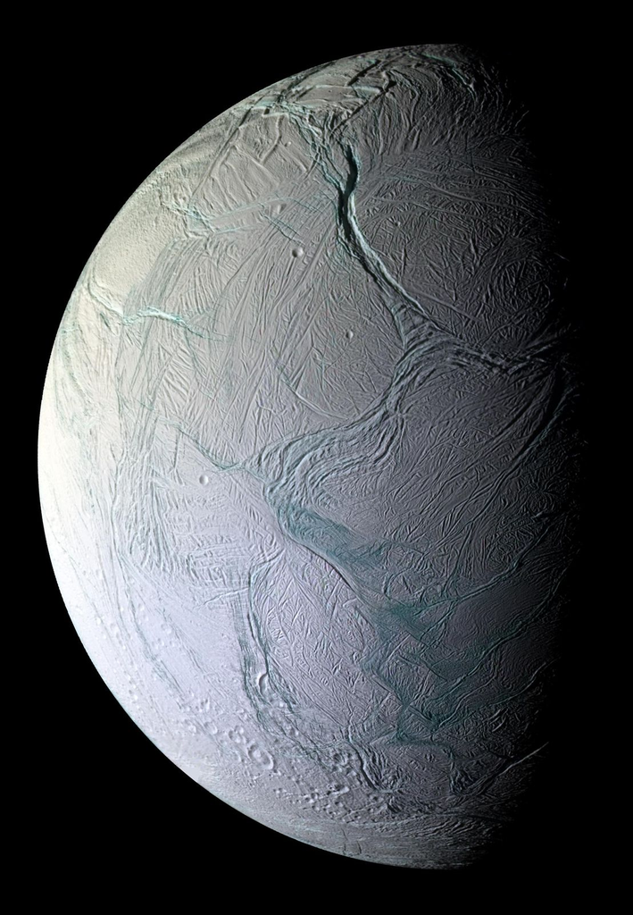

**The tiger stripes**: four cracks about 135 km long, warmer than the ice around them, with about 100 jets along them. NASA/JPL/Space Science Institute

Watch one orbit: squeeze, stretch, spray

[interactive chart not shown]

Speed**×0.5**

The oval shape of the orbit and the stretching of the moon are exaggerated so you can see them. Dione is shown on its own orbit, going around once for every two laps of Enceladus.

Measure: how fast must a grain go to escape?

Enceladus's mass is $1.08\times10^{20}$ kg and its radius is $2.52\times10^{5}$ m. Find its escape speed, $v_{\rm esc} = \sqrt{\dfrac{2GM}{r}}$.

**Reveal**

$v_{\rm esc} = \sqrt{\dfrac{2(6.67\times10^{-11})(1.08\times10^{20})}{2.52\times10^{5}}} = \sqrt{5.7\times10^{4}} = \boxed{240\ \text{m/s}}$, about the speed of a jet airliner. NASA puts the jets at about 400 m/s, faster than that, so part of the spray never comes back: it becomes the E ring. The rest falls back as snow.

### Inside Saturn: a hexagon, helium rain, and floating

Around Saturn's north pole a jet stream runs in a **hexagon**, each side wider than Earth. It has held its shape at least since Voyager saw it in 1981. A jet stream that wobbles in a regular wave can lock into a shape with straight sides; scientists have made hexagons and other polygons in spinning tanks of water in the lab.

Saturn is mostly hydrogen and helium, like Jupiter, but colder inside. Deep down, helium stops mixing with the hydrogen and forms drops that **rain** toward the centre, the way oil separates from vinegar. Falling drops release energy, the leading explanation for why Saturn gives off about **2.4 times** as much energy as it absorbs from the Sun. And Saturn is so light for its size that its average density is less than water's.

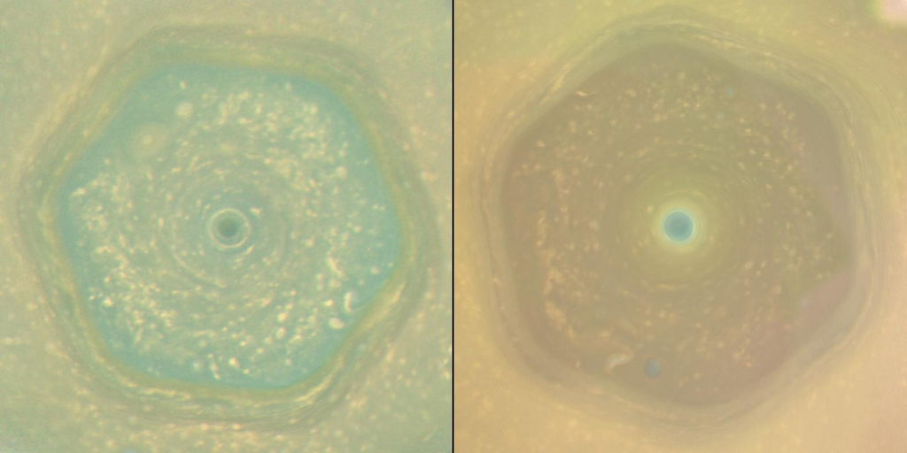

**The hexagon** around Saturn's north pole in 2013 (left) and 2017 (right). It changed colour from blue to gold as northern summer came on: Saturn has seasons too. NASA/JPL-Caltech/Space Science Institute/Hampton University

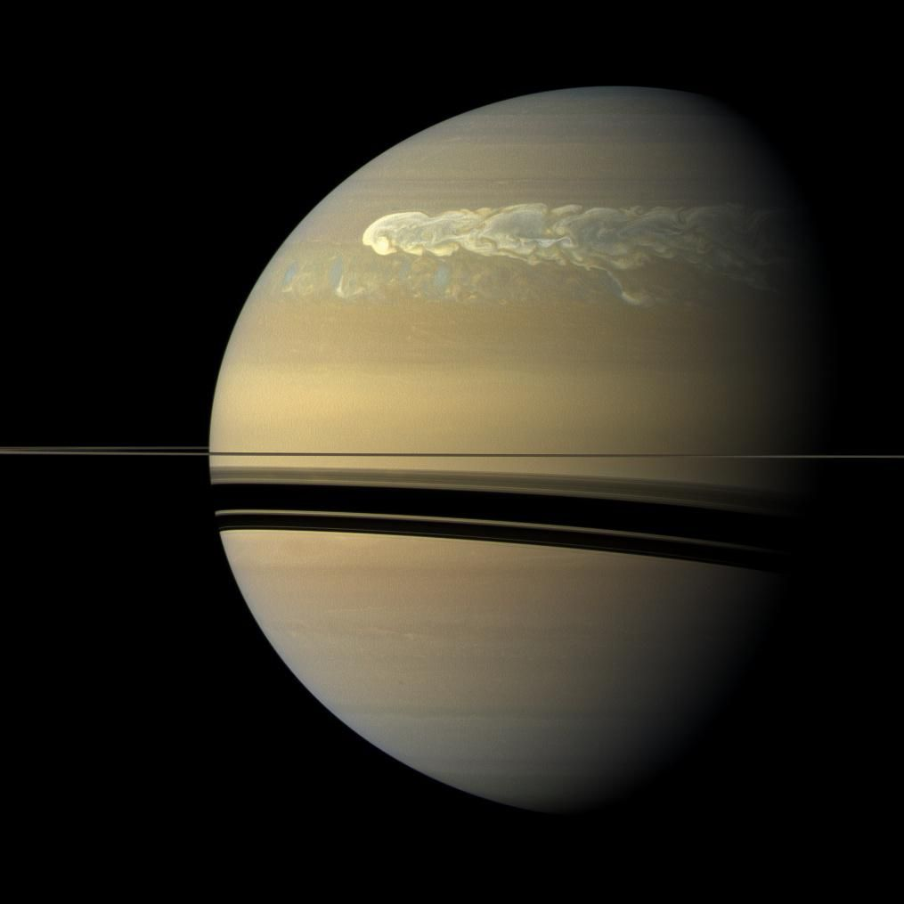

**The Great White Spot** of 2010–11: a storm that wrapped all the way around the planet. Big storms like it erupt about once per Saturn year. NASA/JPL-Caltech/Space Science Institute

The hexagon from above: follow the jet

[interactive chart not shown]

Speed**×1**

A trip inside: helium rain

[interactive chart not shown]

Layer depths are approximate: they come from computer models fitted to Saturn's gravity and to waves in the rings.

Predict first: float or sink? Then drop it in

[interactive chart not shown]

For each world, guess float or sink. Water is 1 g/cm³.

Measure: weigh Saturn with Titan, then find its density

Do it the way the density lab does. Titan orbits Saturn at $a = 1.22\times10^{6}$ km every $p = 15.95$ days. Use $p^2 = \dfrac{a^3}{M_\star}$ ($p$ in years, $a$ in AU, $M_\star$ in solar masses, $M_\odot = 2\times10^{30}$ kg). Then use Saturn's size in the sky this November, 19.3″ across at 8.6 AU, for its radius, and find the bulk density in g/cm³.

**Reveal**

$a = \dfrac{1.22\times10^{6}\ \text{km}}{1.5\times10^{8}\ \text{km/AU}} = 8.13\times10^{-3}$ AU and $p = \dfrac{15.95}{365.25} = 4.37\times10^{-2}$ yr. $M_\star = \dfrac{a^3}{p^2} = \dfrac{(8.13\times10^{-3})^3}{(4.37\times10^{-2})^2} = 2.8\times10^{-4}\,M_\odot = 5.6\times10^{26}\ \text{kg}$, about 94 Earths. Radius: half of 19.3″ is $4.68\times10^{-5}$ rad, so $R = (4.68\times10^{-5})(8.6 \times 1.5\times10^{11}\ \text{m}) = 6.0\times10^{7}$ m. $\rho = \dfrac{M}{\frac{4}{3}\pi R^3} = \dfrac{5.6\times10^{29}\ \text{g}}{\frac43\pi(6.0\times10^{9}\ \text{cm})^3} = \boxed{0.62\ \text{g/cm}^3}$, less than water. (Saturn is flattened, so its average radius is a little smaller than the one across the equator; with that, the accepted value is 0.69 g/cm³. Still less than water.)